# R Visualization

## Visualization

[figure not shown]

## Visualization using ggplot2 package

Although R has some functions built in that provide visualizations, the `ggplot2` package is a go-to for visualization needs. `ggplot2` is a package that is part of a group of packages called `tidyverse`. Since we will use other packages within the `tidyverse`, we can install and load the `tidyverse` library to use `ggplot2`. Alternatively, you can install just `ggplot2` and load the the `ggplot2` package into your environment.

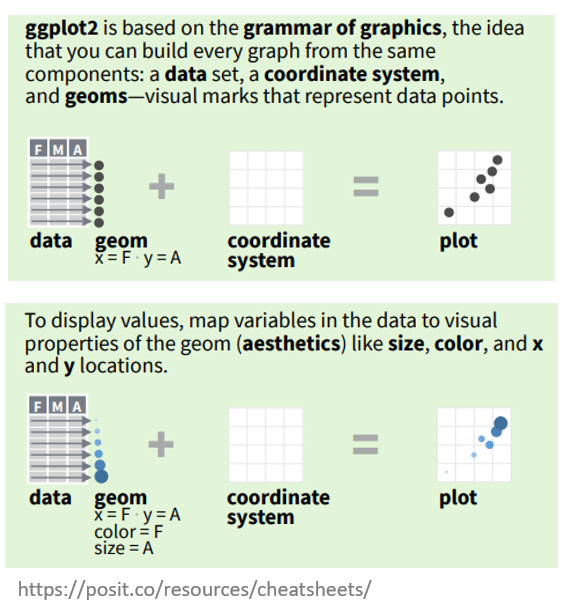

ggplot2 Cheatsheet: https://rstudio.github.io/cheatsheets/data-visualization.pdf

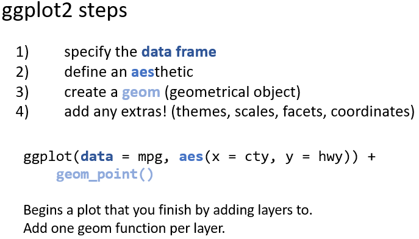

*Note: This tutorial builds from R for Data Science (*https://r4ds.hadley.nz/data-visualize*). See https://ggplot2.tidyverse.org/ for other great resources.*

## diamonds Data Frame

We will be working with a data frame that is included in the `ggplot2` package.

A data frame is a rectangular collection of variables (in the columns) and observations (in the rows). `diamonds` contains the prices and other attributes of almost 54,000 diamonds.

Take a look at the data.

We can also load the data into the RStudio global environment.

Or get more information using `?diamonds`.

## Histogram

Show the distribution of weights of the diamonds (carats) in “bins.” Each bin includes a range of values where the frequency of the data is shown as the height of the bar.

### ggplot Histogram (default settings)

### ggplot: add specifications

### ggplot: add a layer for labels and theme

### ggplot: store the plot as an object

### ggplot: add interactivity with plotly

`plotly` is another library that allows interactivity with ggplot visuals by converting `ggplot` objects into `plotly` objects. You may need to install the `plotly` package before loading the library.

Or, without loading the library, we can access `ggplotly` function using `::`. This is true for any installed packages/libraries in R.

## Density Plot

A density plot shows the probability of observations falling within a sliding window along the variable of interest (in this case “carat”). Density plots are typically used to show data over a continuous interval or time period.

`fill` is generally used for coloring enclosed areas while `color` is typically used to set the color of the outline or of elements that don’t have fillable areas like lines or points.

## Scatterplot

Now let’s look at the distribution of price across different diamond weights (“carats”).

### Exercise

Create a scatterplot of price and carat where each point is colored purple.

While this plot is interesting, it would be useful to add another dimension. Let’s look at the distribution of “clarity” across this scatterplot.

## Faceted plots

These plots are “small multiples” of the data. Rather than viewing distribution of different clarities across carat and price, we can look at separate plots at once.

## Boxplots

A boxplot is another good way to look at a distribution of data. If it is one-dimension, using only one variable *y* although `ggplot2` requires an number for *x*.

We can create multiple boxplots across a categorical variable as well.

## Bar Charts

### Counts

Bar charts use the geom `geom_bar` with the most basic form utilizing a *count* of observations in the data. When no *y* variable is present, it automatically generates the bars by calculating the rows. This is considered a **stat** (or statistical transformation) where *count* is `geom_bar`’s default stat.

### Horizontal Orientation

Method 1: Map to the `y` variable instead of `x`.

Method 2: “Coord Flip”

### Dodged bar chart

`position = "dodge"` is helpful for comparing groups side by side.

### Proportions

`ggplot2` has other stats that can be referenced like “prop” which shows proportions. Note that an additional argument for *group* must also be added.

We can clean modify the y axis to show percentage by adding `scale_y_continuous(labels = scales::percent)`.

### Set bar length equal to a variable

If we want to use one of our data variables as the y axis, we add the argument `stat = 'identity'`. This tells R that the statistical transformation is to take the actual values of whatever y argument is defined in the aesthetic mapping.

### Exercise

Create a bar graph that shows median price by clarity.

## Exercise with `mpg` data

Let’s look at another dataset included in the `ggplot2` package called `mpg`.

Look at the description of the data with `?mpg`. Load `mpg` into your environment to take a look.

1) Create a scatterplot using the variables x = `displ` and y = `hwy` and a color aesthetic of another variable like `class`.

2) How would you color all points the same color?

*More ggplot2 practice: https://posit.cloud/learn/recipes*